# BEE552 Biometry Week 4

Maria Feiler

2/16/2022

## My Learning Journey

*Over the last week, I participated in Biometry in the following ways:*

- I asked / answered **5** questions posed in class.
- I asked **0** questions in Slack.
- I answered **1** questions posed by other students on Slack.
- I came to Heather’s office hours: **No**
- I came to Jose’s office hours: **No**
- I met with Heather or Jose separately from office hours: **No**

*Anything not falling into one of the above categories?*

> **No**

*On a scale of 1 (no knowledge) to 10 (complete expert), how would I rate my* *comfort with R programming after this week?*

> **6**

*Any topics from last week that you are still confused about?*

> **Doing fine for now**

## Problem Set

### Part 1

*We will be using a recently published dataset on ancient rings and ribs that may have been used as early forms of money. These data come from the paper “The origins of money: Calculation of similarity indexes demonstrates the earliest development of commodity money in prehistoric Central Europe” by M.H.G. Kuijpers and C. Popa (PLoS ONE, January 20, 2021).*

*Download the data in the file “rings_and_ribs.csv”.*

```r
money <- read_excel("journal.pone.0240462.s002.xlsx",
                    sheet = 1
                    )

head(money, n = 4)
```

```
## # A tibble: 4 x 8
##   Location Country Zone  Date  `Weight (g)` Type  Museum           Source
##   <chr>    <chr>   <chr> <chr>        <dbl> <chr> <chr>            <chr>
## 1 Alzgern  Germany 1     EBA          145.  Rib   Private Property Lenerz- de W~
## 2 Alzgern  Germany 1     EBA           92.4 Rib   Private Property Lenerz- de W~
## 3 Alzgern  Germany 1     EBA          159.  Rib   Private Property Lenerz- de W~
## 4 Alzgern  Germany 1     EBA          148.  Rib   Private Property Lenerz- de W~
```

#### Question 1

*For now, let’s group all the locations together. Make a histogram of ring weight.*

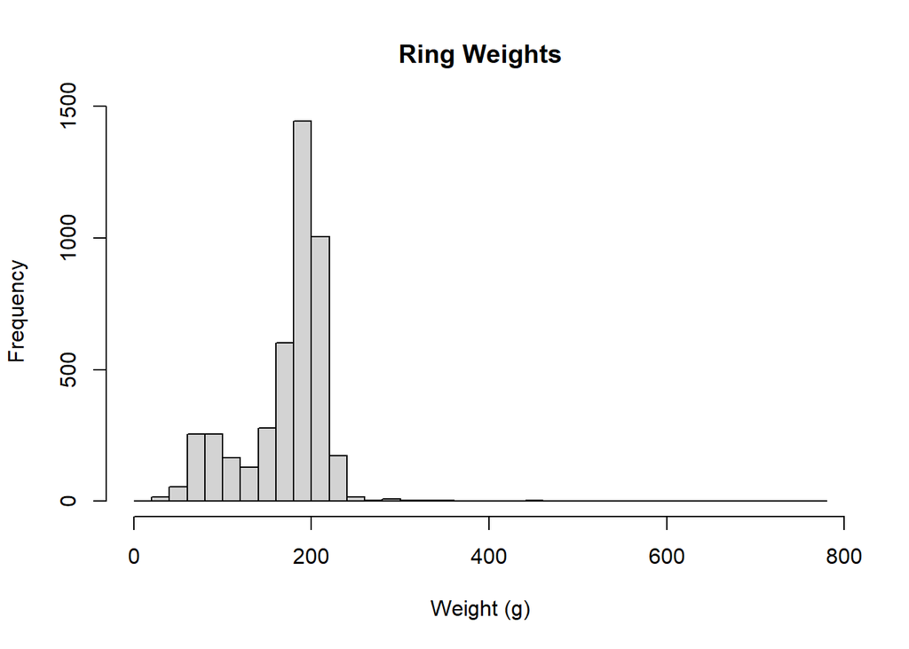

#### Question 2

*What is the FORMULA for the sample mean and standard deviation (in other words, what is the formula you would want to use if you wanted to estimate the population mean [the $\mu$ parameter assuming a normal distribution] and the population variance [$\sigma^2$ if we assume a normal distribution] from a sample that represented a random subset of the entire population)?*

$$\begin{aligned}
\overline{X} &= \frac{\sum^{n}_{i=1}X_i}{n} \\
S &= \sqrt{\frac{\sum^{n}_{i=1}(X_i - \overline{X})^2}{n-1}}
\end{aligned}$$

#### Question 3

*What is the population about which we are trying to make inference?*

```
FALSE The population is the total collection of rings and ribs ever used for currency in the context of Germany, Austria, the Czech Republic, and Poland during this time period.
```

#### Question 4

*Using R, what are the mean and the standard deviation of ring weight?*

```
FALSE The mean of the ring weights is 172.633.
```

```
FALSE The standard deviation of ring weights is 48.296.
```

#### Question 5

*What is the formula for the standard error of the mean (heretofore s.e.)?*

$$SEM = \sqrt{\frac{S^{2}}{n}}$$

#### Question 6

*Describe the difference between the s.e. (of the mean) and the s.d.*

```
The standard deviation is a measure of the variance of your sample The standard error of the mean describes how close your sample mean approximates the population mean.
```

#### Question 7

*Finish the sentence: The standard error is the standard deviation of…*

```
...the mean.
```

#### Question 8

*Use the MASS package’s ‘fitdistr’ function to fit a normal distribution to the ring weight data. Do you get the roughly same answer as above?*

```r
ringWeightFit <- fitdistr(money["Type" = "Ring",]$`Weight (g)`,
                           "normal")
```

```
The difference between the calculated mean and the mean from fitdistr() is 0.
```

```
The difference between the calculated standard deviation and the standard deviation from fitdistr() is -0.00546.
```

#### Question 9

*Why might it not be valid to group the different locations when summarizing the data?*

```
Though there might be differences between the rings used as currency in each country, all were considered to have moneytary value and might have changed hands outside of country/political entity lines. Since they are all from the same time period, if you want to characterize how the earliest money worked, you must use all the material that was used as money.
```

#### Question 10

*Using the R command ‘boxplot’, create a boxplot to compare ring weight across different countries.*

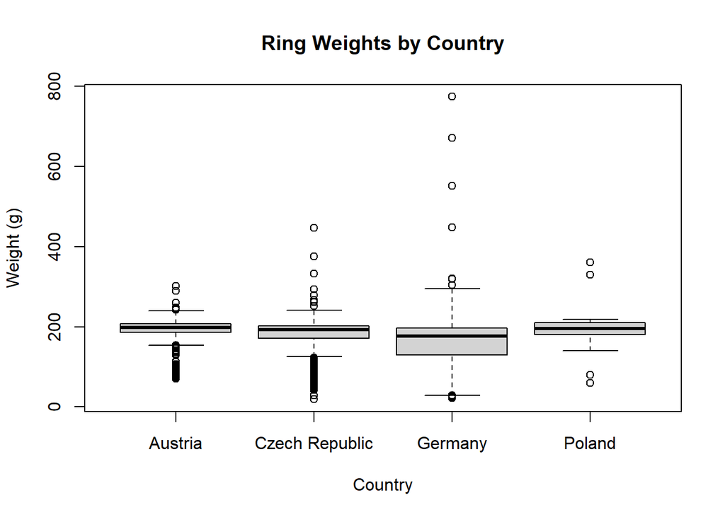

#### Question 11

*Make the case (in words and/or mathematically) that average ring weight in Germany is or is not statistically different from the average ring weight in Austria.*

```r
t.test(ringsByCountry$value[ringsByCountry$Country == "Germany"],
       ringsByCountry$value[ringsByCountry$Country == "Austria"]
       )
```

```
##
##  Welch Two Sample t-test
##
## data:  ringsByCountry$value[ringsByCountry$Country == "Germany"] and ringsByCountry$value[ringsByCountry$Country == "Austria"]
## t = -20.77, df = 3137.9, p-value < 2.2e-16
## alternative hypothesis: true difference in means is not equal to 0
## 95 percent confidence interval:
##  -32.94036 -27.25762
## sample estimates:
## mean of x mean of y
##  161.9096  192.0086
```